# python_notebook

## Additional Customization:

- Color palettes: Use the palette parameter to set custom colors.
- Binning: Control the number of bins with the bins parameter.
- Density estimation: Adjust the KDE bandwidth with kde_kws.
- Axes labels and title: Add labels and titles using plt.xlabel, plt.ylabel, and plt.title.

Seaborn's histplot is a versatile tool for understanding the distribution of your data. By combining it with other Seaborn functions and Matplotlib customizations, you can create informative and visually appealing histograms.

```python
# SNS histogram or Distribution plot
diamond = sns.load_dataset("diamonds")
diamond.head()
```

|  | carat | cut | color | clarity | depth | table | price | x | y | z |
| --- | --- | --- | --- | --- | --- | --- | --- | --- | --- | --- |
| 0 | 0.23 | Ideal | E | SI2 | 61.5 | 55.0 | 326 | 3.95 | 3.98 | 2.43 |
| 1 | 0.21 | Premium | E | SI1 | 59.8 | 61.0 | 326 | 3.89 | 3.84 | 2.31 |
| 2 | 0.23 | Good | E | VS1 | 56.9 | 65.0 | 327 | 4.05 | 4.07 | 2.31 |
| 3 | 0.29 | Premium | I | VS2 | 62.4 | 58.0 | 334 | 4.20 | 4.23 | 2.63 |
| 4 | 0.31 | Good | J | SI2 | 63.3 | 58.0 | 335 | 4.34 | 4.35 | 2.75 |

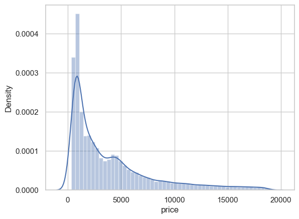

```python
sns.distplot(diamond['price'])
plt.show()
```

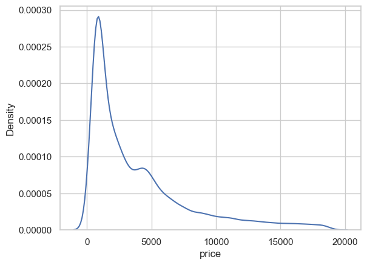

```python
sns.distplot(diamond['price'], hist=False)
plt.show()
```

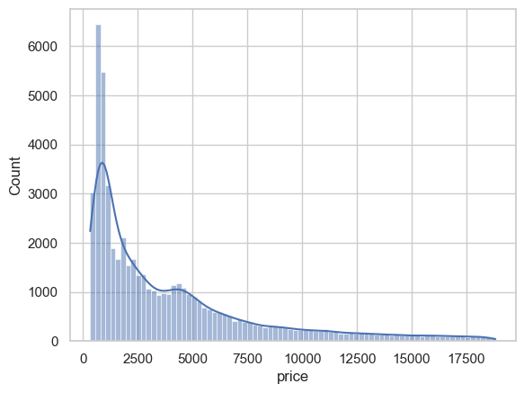

```python
sns.histplot(x="price", data=diamond, kde=True)
```

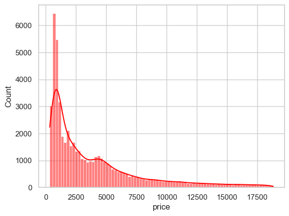

```python
sns.histplot(diamond['price'], kde=True, color="red")
```

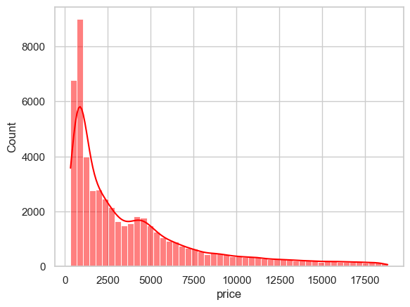

```python
sns.histplot(diamond['price'], kde=True, color="red", bins=50)
```

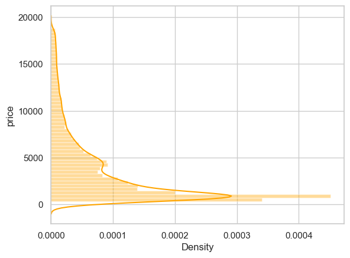

```python
sns.distplot(diamond['price'], kde=True, color="orange", bins=50, vertical=True)
```

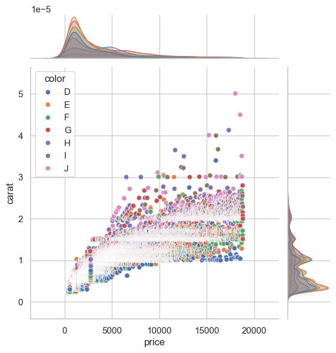

```python
##JointPlot

sns.jointplot(x="price", y="carat", data=diamond, hue="color")
plt.show()
```

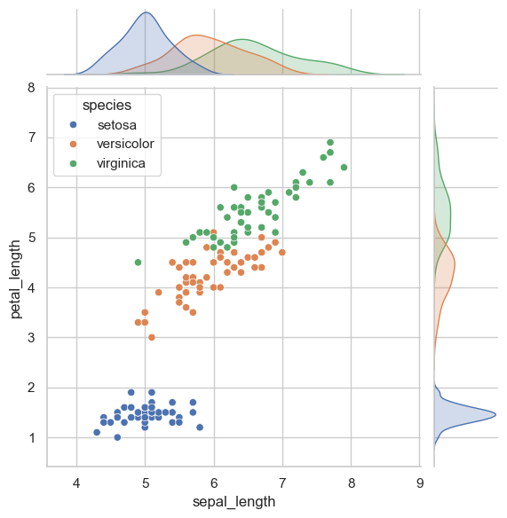

```python
iris = pd.read_csv('data/iris.csv')

sns.jointplot(x="sepal_length", y="petal_length", data=iris, hue="species")
plt.show()
```

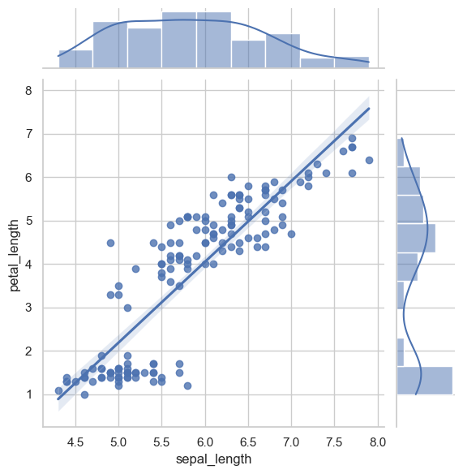

```python
sns.jointplot(x="sepal_length", y="petal_length", data=iris, kind="reg")
plt.show()
```

## Seaborn Boxplot

Seaborn's boxplot function is used to visualize the distribution of numerical data across different categories. It provides a compact representation of the data, showing the median, quartiles, and potential outliers.

### Key Parameters:

- x: The name of the categorical variable to be used on the x-axis.
- y: The name of the numerical variable to be visualized.
- data: The dataset to be used.
- hue: Optional categorical variable for creating multiple boxplots within each category.
- width: Width of the boxes.
- palette: Color palette for the boxes.
- whis: Determines the length of the whiskers.
- showfliers: Whether to show outliers.

## Additional Customization:

- orient: To create horizontal boxplots.
- saturation: Adjust the color saturation.
- ax: To plot on a specific matplotlib axes.
- Other aesthetic parameters from Matplotlib can be used for further customization.

Seaborn's boxplot is a powerful tool for comparing distributions across different categories. By exploring the different parameters and customization options, you can create informative and visually appealing boxplots.

```python
# BOXPLOT
churn = pd.read_csv('data/Telco-Customer-Churn.csv')
churn.head()
```

|  | customerID | gender | SeniorCitizen | Partner | Dependents | tenure | PhoneService | MultipleLines | InternetService | OnlineSecurity | ... | DeviceProtection | TechSupport | StreamingTV | StreamingMovies | Contract | PaperlessBilling | PaymentMethod | MonthlyCharges | TotalCharges | Churn |
| --- | --- | --- | --- | --- | --- | --- | --- | --- | --- | --- | --- | --- | --- | --- | --- | --- | --- | --- | --- | --- | --- |
| 0 | 7590-VHVEG | Female | 0 | Yes | No | 1 | No | No phone service | DSL | No | ... | No | No | No | No | Month-to-month | Yes | Electronic check | 29.85 | 29.85 | No |
| 1 | 5575-GNVDE | Male | 0 | No | No | 34 | Yes | No | DSL | Yes | ... | Yes | No | No | No | One year | No | Mailed check | 56.95 | 1889.5 | No |
| 2 | 3668-QPYBK | Male | 0 | No | No | 2 | Yes | No | DSL | Yes | ... | No | No | No | No | Month-to-month | Yes | Mailed check | 53.85 | 108.15 | Yes |
| 3 | 7795-CFOCW | Male | 0 | No | No | 45 | No | No phone service | DSL | Yes | ... | Yes | Yes | No | No | One year | No | Bank transfer (automatic) | 42.30 | 1840.75 | No |
| 4 | 9237-HQITU | Female | 0 | No | No | 2 | Yes | No | Fiber optic | No | ... | No | No | No | No | Month-to-month | Yes | Electronic check | 70.70 | 151.65 | Yes |

5 rows × 21 columns

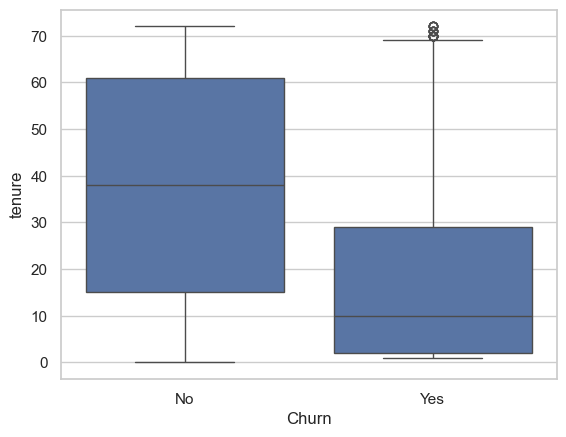

```python
sns.boxplot(x="Churn", y="tenure", data=churn)
plt.show()
```

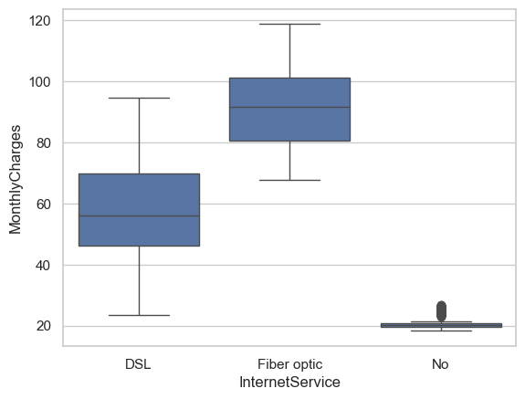

```python
sns.boxplot(x='InternetService', y='MonthlyCharges', data=churn)
plt.show()
```

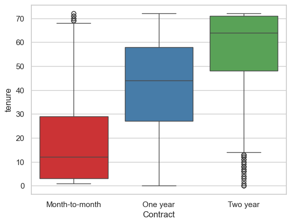

```python
sns.boxplot(x='Contract', y='tenure', data=churn, palette="Set1")
plt.show()
```

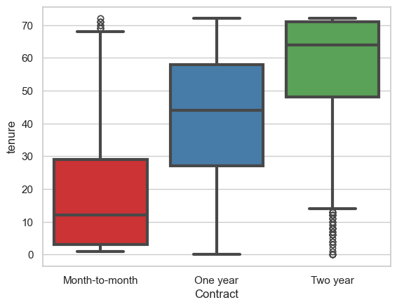

```python
sns.boxplot(x='Contract', y='tenure', data=churn, palette="Set1", linewidth=3)
plt.show()
```

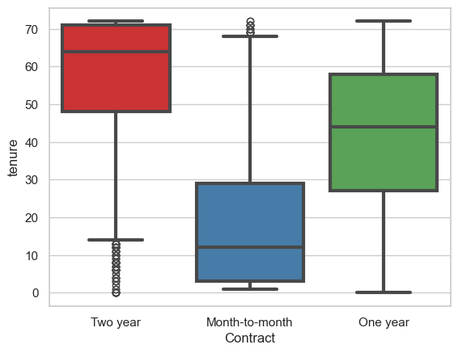

```python
sns.boxplot(x='Contract', y='tenure', data=churn, palette="Set1", linewidth=3, order=['Two year','Month-to-month', 'One year'])
plt.show()
```

# GenAI

Generative AI, or Gen AI, functions by employing a neural network to analyse data patterns and generate new content based on those patterns.

- Discriminative Classifies data in a way similar to judge
- Generative AI Create, transforms or generates its own content like an artist

# Introduction to Generative AI Applications

Overview:

- Generative AI refers to algorithms that enable machines to produce content that is not only new and original but also reflective of the data they were trained on.
- Includes models like GANs (Generative Adversarial Networks), VAEs (Variational Autoencoders), and Transformer-based models (e.g., GPT).

Significance:

- Creativity Boost: Enhances creative processes by providing novel content ideas.
- Efficiency: Automates content creation, saving time and resources.
- Personalization: Generates personalized content for users in various applications.

# Development Environment Setup

Setting up the development environment:

- Step 1: Open Command Line Interface (CLI)
  - For Windows: Use Command Prompt or PowerShell.
  - For macOS/Linux: Use Terminal.
- Step 2: Install Libraries using pip
  - pip install numpy
  - pip install flask
  - pip install streamlit
  - pip install torch torchvision torchaudio
  - pip install transformers
  - pip install python-dotenv
- Step 3: Create a .env file Create a file named .env at the root of your project. Inside, add your environment variables in the format KEY=VALUE, one per line:

  API_KEY=your_api_key

  DATABASE_URL=your_database_url

  SECRET_KEY=your_secret_key

  Important: Make sure to add .env to your .gitignore file to prevent committing sensitive information to your version control system.
- Step 4: Load the environment variables In your Python script, import the dotenv module and load the .env file:

  from dotenv import load_dotenv

  import os

  load_dotenv()

### Access environment variables

  api_key = os.environ.get('API_KEY')

  database_url = os.environ.get('DATABASE_URL')

  secret_key = os.environ.get('SECRET_KEY')

# Verify the Installation

Step 1: Check Python Installation

Open CLI and type: python --version

Ensure it returns the installed version of Python.

Step 2: Verify Library Installations

Open Python interactive shell: python

Import each library to ensure they are installed correctly:

- import numpy
- import flask
- import streamlit
- import torch
- import transformers

## Introduction to OpenAI GPT API

API Features

- Text generation, completion, and conversation capabilities.
- Fine-tuning and customization for specific tasks.

Getting Started

- Sign up for an API key on the OpenAI website.
- Refer to the API documentation for detailed instructions.

## Flask ChatGPT App

Basic Setup:

Objective: Build a basic chat application using Flask and OpenAI GPT API.

Components:

- Flask for web framework.
- OpenAI GPT API for generating responses.

Let's explore more with a demo !!

## Step 1: Setting Up the Environment

First, make sure you have Python and the required libraries installed. You can create a virtual environment and install the necessary packages:

```
python -m venv venv
source venv/bin/activate # On Windows use "venv\Scripts\activate"
```

Explanation:

- python: This invokes the Python interpreter. Depending on your system setup, you might need to specify python3 instead of python to use Python 3.
- -m venv: This option tells Python to run the venv module as a script. The venv module is used to create virtual environments.
- venv: This is the name of the directory where the virtual environment will be created. You can name this directory anything you like, but venv is a common convention.

## Step 2: Create the Flask Application

Create a new directory for your project

```
mkdir gtp_chat_app
cd gpt_chat_app
```

### Step 3. Create the main flask application file (app.py)

```python
from flask import Flask, request, jsonify, render_template
import requests
import time

from dotenv import load_dotenv
import os

load_dotenv()

# Access environment variables
# OpenAI API key (Note: It's best to keep API keys secure and not hardcode them)
OPENAI_API_KEY = os.environ.get('OPENAI_API_KEY')

# Initialize the Flask application
app = Flask(__name__)

# Define the route for the home page
@app.route('/')
def index():
    return render_template('index.html')  # Render the 'index.html' template

# Define the route for the chat endpoint, which accepts POST requests
@app.route('/chat', methods=["POST"])
def chat():
    # Get the user's message from the JSON payload of the request
    user_input = request.json.get('message')
    print(f"Received message: {user_input}")  # Debugging statement to print the received message

    # Get the response from GPT-3
    response = get_gpt_response(user_input)
    print(f"GPT-3 response: {response}")  # Debugging statement to print the GPT-3 response

    # Return the GPT-3 response as a JSON object
    return jsonify({'response': response})

def get_gpt_response(user_input, retry_count=3):
    # Set up the headers for the API request
    headers = {
        'Authorization': f'Bearer {OPENAI_API_KEY}',
        'Content-Type': 'application/json'
    }

    # Set up the data for the API request
    data = {
        'model': 'gpt-3.5-turbo-16k',  # Use a current model
        'messages': [{'role': 'user', 'content': user_input}],  # User's input message
        'max_tokens': 300  # Limit the response length
    }
    for attempt in range(retry_count):
        response = requests.post('https://api.openai.com/v1/chat/completions', headers=headers, json={})

        if response.status_code == 200:
            try:
                # Return the content of the first choice in the response
                return response.json()['choices'][0]['message']['content']
            except (KeyError, IndexError) as e:
                print(f"Error parsing response JSON: {e}")  # Print the error
                print(f"Response JSON: {response.json()}")  # Print the full response JSON
                return "An error occurred while processing the response from OpenAI."
        elif response.status_code == 429:
            # Handle rate limiting errors
            print(f"Request to OpenAI failed with status code: {response.status_code}")
            print(f"Response: {response.text}")
            if attempt < retry_count - 1:
                print("Retrying...")
                time.sleep(2 ** attempt)  # Exponential backoff before retrying
            else:
                return "You have exceeded your current quota. Please check your plan and billing details."
        else:
            # Handle other errors
            print(f"Request to OpenAI failed with status code: {response.status_code}")
            print(f"Response: {response.text}")
            return "An error occurred while communicating with OpenAI."

# Run the Flask application
if __name__ == '__main__':
    app.run(port=5000, debug=True) # Run the app in debug mode
```